# HW1

Burak Şimşek - IE582 - Fall 2020

11/14/2020

```r
#loading libraries
library(ggplot2)
library(dplyr)
library(tidyverse)
```

# English Premier Leage Statistics from 2018-2019 season to 2020-2021 season

```r
#reading dataframes
data2020=read.csv("https://github.com/BU-IE-582/fall20-buraksimsekkk/raw/master/HW1/2020-2021.csv")
data2019=read.csv("https://github.com/BU-IE-582/fall20-buraksimsekkk/raw/master/HW1/2019-2020.csv")
data2018=read.csv("https://github.com/BU-IE-582/fall20-buraksimsekkk/raw/master/HW1/2018-2019.csv")

#combining datas
all_data <- bind_rows(data2020 , data2019 , data2018)
```

## Task 1

## Task 1.1

#### Third histogram shows the frequency of differance of the goals of home team and the goals of away team among 3 seasons.

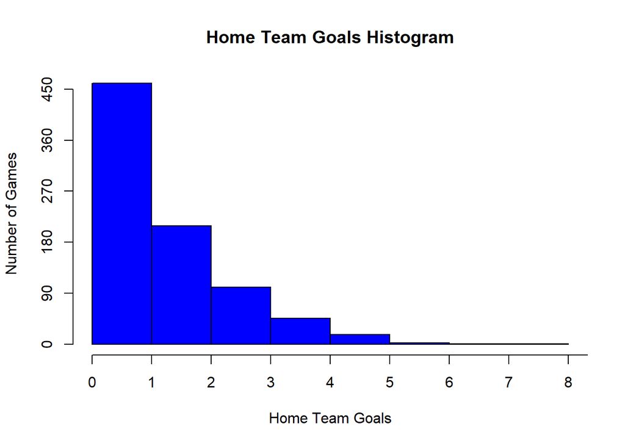

```r
#plotting histograms
home_hist <- hist(all_data$FTHG , breaks=10, col="blue" , xlab="Home Team Goals", ylab="Number of Games", main="Home Team Goals Histogram" , xaxp=c(0,10,10) , yaxp=c(0,450,5))
```

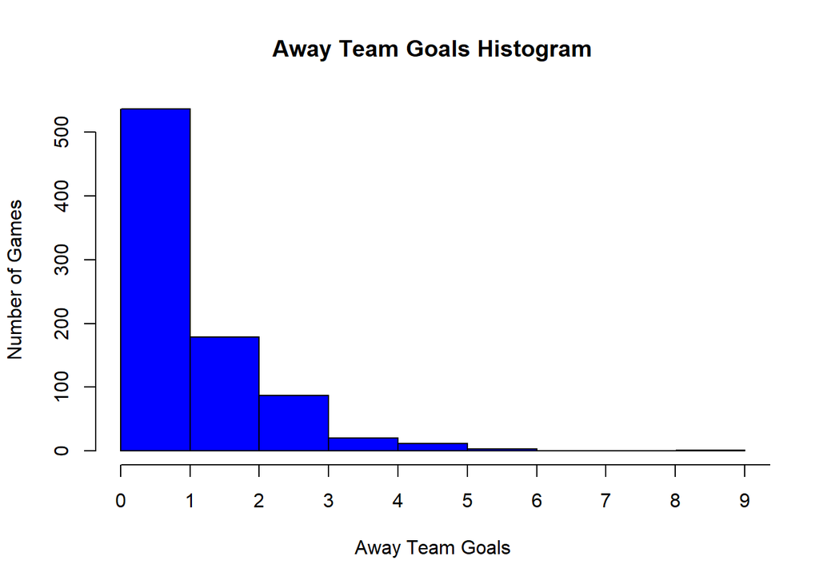

```r
away_hist <- hist(all_data$FTAG , breaks=10, col="blue" , xlab="Away Team Goals", ylab="Number of Games", main="Away Team Goals Histogram" , xaxp=c(0,10,10))
```

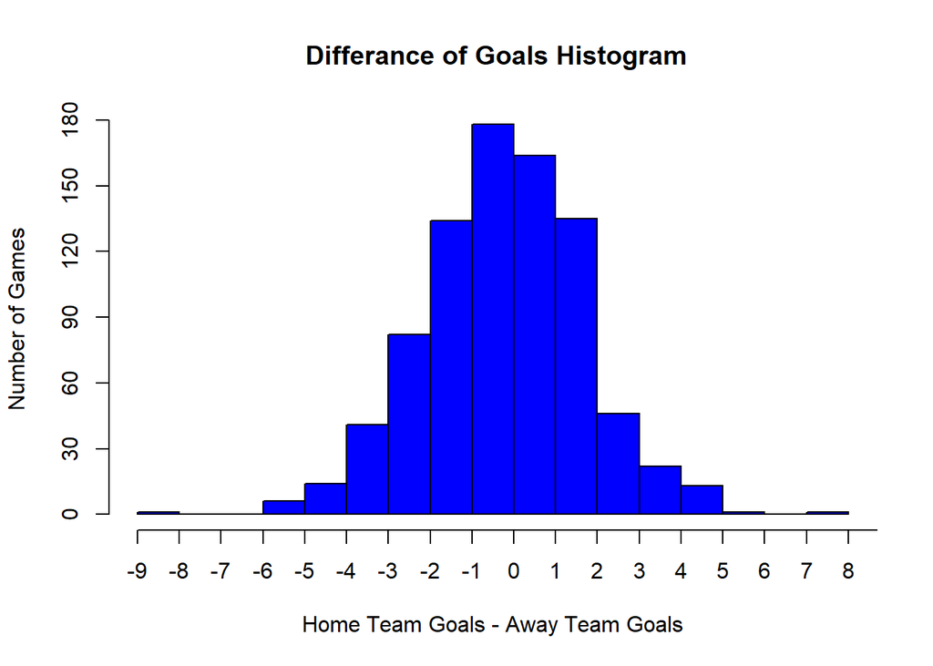

```r
diff_hist <- hist((all_data$FTHG - all_data$FTAG) , breaks=20, col="blue" , xlab="Home Team Goals - Away Team Goals", ylab="Number of Games", main=" Differance of Goals Histogram" , xaxp=c(-9,9,18) , yaxp=c(0,180,6) )
```

## Task 2

## Task 2.1

Four bookmakers are chosen and their home win, draw and away win probabilities; P(Home Win), P(Draw) and P(Away Win) respectively, will be calculated.

```r
probs  <- all_data %>% mutate( Home_prob_BWH = 1 / BWH,
                               Draw_prob_BWD = 1 / BWD,
                               Away_prob_BWA = 1 / BWA,

                               Home_prob_IWH = 1 / IWH,
                               Draw_prob_IWD = 1 / IWD,
                               Away_prob_IWA = 1 / IWA,

                               Home_prob_PSH = 1 / PSH,
                               Draw_prob_PSD = 1 / PSD,
                               Away_prob_PSA = 1 / PSA,

                               Home_prob_WHH = 1 / WHH,
                               Draw_prob_WHD = 1 / WHD,
                               Away_prob_WHA = 1 / WHA)
```

## Task 2.2

#### Probability of home win, draw and away win are normalized.

```r
normalized  <- probs %>% mutate( norm_BWH = Home_prob_BWH / (Home_prob_BWH + Draw_prob_BWD + Away_prob_BWA),
                                 norm_BWD = Draw_prob_BWD / (Home_prob_BWH + Draw_prob_BWD + Away_prob_BWA),
                                 norm_BWA = Away_prob_BWA / (Home_prob_BWH + Draw_prob_BWD + Away_prob_BWA),

                                 norm_IWH = Home_prob_IWH / (Home_prob_IWH + Draw_prob_IWD + Away_prob_IWA),
                                 norm_IWD = Draw_prob_IWD / (Home_prob_IWH + Draw_prob_IWD + Away_prob_IWA),
                                 norm_IWA = Away_prob_IWA / (Home_prob_IWH + Draw_prob_IWD + Away_prob_IWA),

                                 norm_PSH = Home_prob_PSH / (Home_prob_PSH + Draw_prob_PSD + Away_prob_PSA),
                                 norm_PSD = Draw_prob_PSD / (Home_prob_PSH + Draw_prob_PSD + Away_prob_PSA),
                                 norm_PSA = Away_prob_PSA / (Home_prob_PSH + Draw_prob_PSD + Away_prob_PSA),

                                 norm_WHH = Home_prob_WHH / (Home_prob_WHH + Draw_prob_WHD + Away_prob_WHA),
                                 norm_WHD = Draw_prob_WHD / (Home_prob_WHH + Draw_prob_WHD + Away_prob_WHA),
                                 norm_WHA = Away_prob_WHA / (Home_prob_WHH + Draw_prob_WHD + Away_prob_WHA)  )
```

## Task 2.3

#### For four bookmakers P(home win) - P(away win) on x-axis and P(tie) on y-axis are plotted.

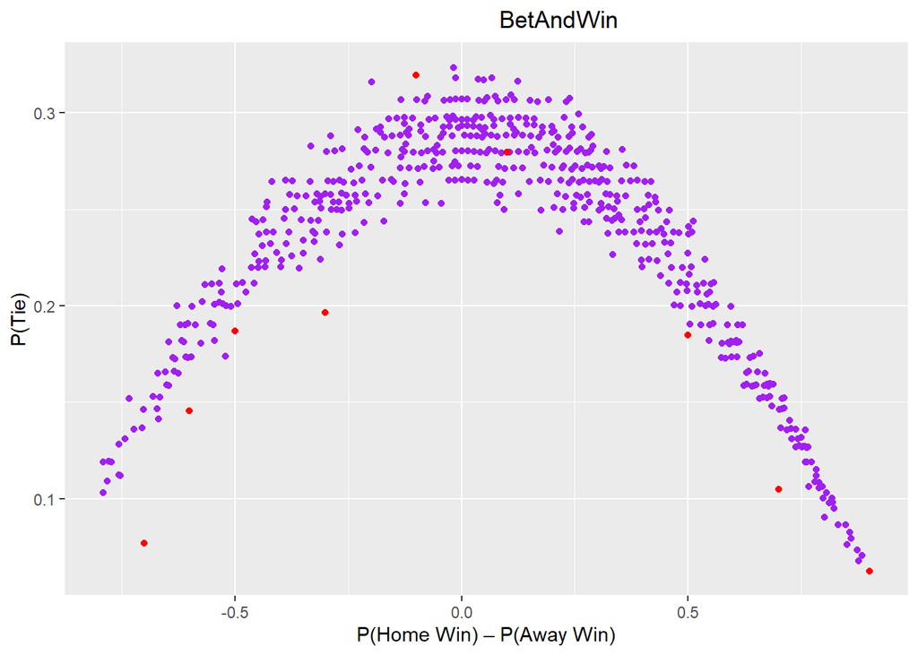

```r
BW_probs <- normalized %>% select(FTR, norm_BWH, norm_BWD, norm_BWA) %>% mutate(norm_BW_HA = norm_BWH - norm_BWA, intervals = cut(norm_BW_HA, breaks = seq(-1, 1, 0.2))) %>% group_by(intervals) %>% mutate(real_draws=sum(FTR=="D")/n()) %>% ungroup()

BW_probs$intervals_number <- as.numeric(BW_probs$intervals)

BW_probs$intervals_number[BW_probs$intervals_number==1]  <- -0.9
BW_probs$intervals_number[BW_probs$intervals_number==2]  <- -0.7
BW_probs$intervals_number[BW_probs$intervals_number==3]  <- -0.6
BW_probs$intervals_number[BW_probs$intervals_number==4]  <- -0.5
BW_probs$intervals_number[BW_probs$intervals_number==5]  <- -0.3
BW_probs$intervals_number[BW_probs$intervals_number==6]  <- -0.1
BW_probs$intervals_number[BW_probs$intervals_number==7]  <-  0.1
BW_probs$intervals_number[BW_probs$intervals_number==8]  <-  0.5
BW_probs$intervals_number[BW_probs$intervals_number==9]  <-  0.7
BW_probs$intervals_number[BW_probs$intervals_number==10] <-  0.9

ggplot(BW_probs) + geom_point(aes(x=norm_BW_HA, y=norm_BWD), color="purple") + geom_point(aes(x=intervals_number, y=real_draws), color="red") +  xlab("P(Home Win) – P(Away Win)") + ylab("P(Tie)") + ggtitle("BetAndWin") + theme(plot.title=element_text(hjust = 0.6))
```

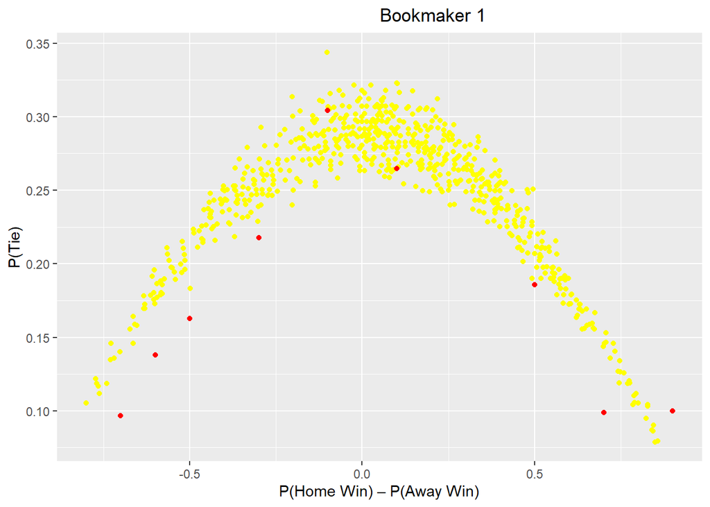

```r
IW_probs <- normalized %>% select(FTR, norm_IWH, norm_IWD, norm_IWA) %>% mutate(norm_IW_HA = norm_IWH - norm_IWA, intervals = cut(norm_IW_HA, breaks = seq(-1, 1, 0.2))) %>% group_by(intervals) %>% mutate(real_draws=sum(FTR=="D")/n()) %>% ungroup()

IW_probs$intervals_number <- as.numeric(IW_probs$intervals)

IW_probs$intervals_number[IW_probs$intervals_number==1]  <- -0.9
IW_probs$intervals_number[IW_probs$intervals_number==2]  <- -0.7
IW_probs$intervals_number[IW_probs$intervals_number==3]  <- -0.6
IW_probs$intervals_number[IW_probs$intervals_number==4]  <- -0.5
IW_probs$intervals_number[IW_probs$intervals_number==5]  <- -0.3
IW_probs$intervals_number[IW_probs$intervals_number==6]  <- -0.1
IW_probs$intervals_number[IW_probs$intervals_number==7]  <-  0.1
IW_probs$intervals_number[IW_probs$intervals_number==8]  <-  0.5
IW_probs$intervals_number[IW_probs$intervals_number==9]  <-  0.7
IW_probs$intervals_number[IW_probs$intervals_number==10] <-  0.9

ggplot(IW_probs) + geom_point(aes(x=norm_IW_HA, y=norm_IWD), color="yellow") + geom_point(aes(x=intervals_number, y=real_draws), color="red") +  xlab("P(Home Win) – P(Away Win)") + ylab("P(Tie)") + ggtitle("Bookmaker 1") + theme(plot.title=element_text(hjust = 0.6))
```

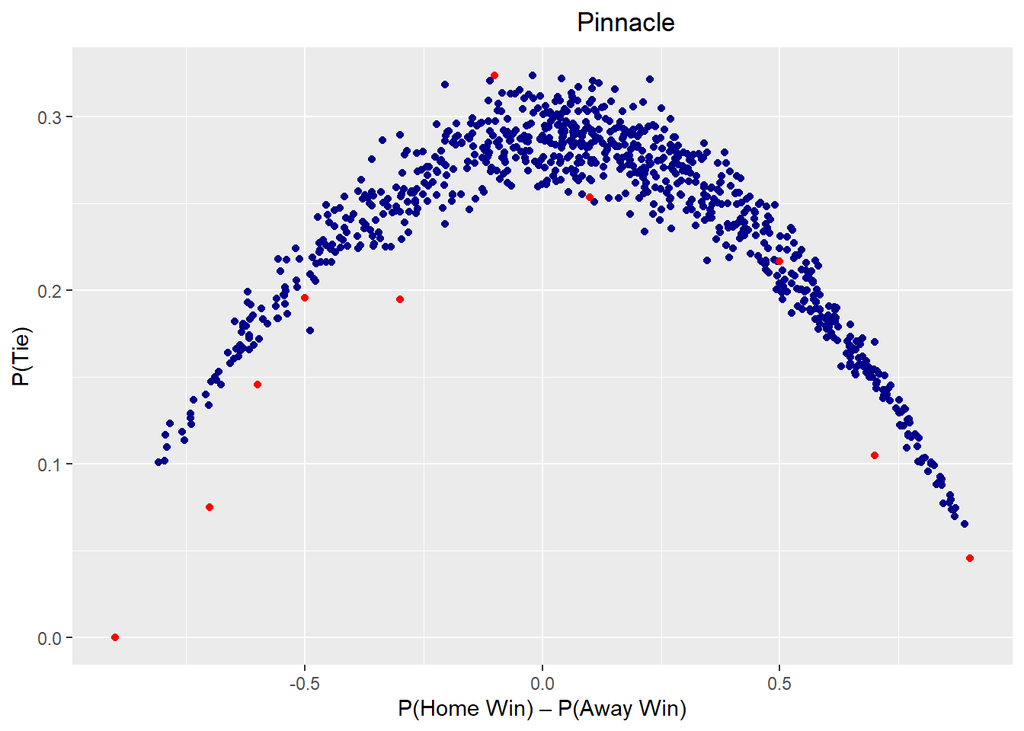

```r
PS_probs <- normalized %>% select(FTR, norm_PSH, norm_PSD, norm_PSA) %>% mutate(norm_PS_HA = norm_PSH - norm_PSA, intervals = cut(norm_PS_HA, breaks = seq(-1, 1, 0.2))) %>% group_by(intervals) %>% mutate(real_draws=sum(FTR=="D")/n()) %>% ungroup()

PS_probs$intervals_number <- as.numeric(PS_probs$intervals)

PS_probs$intervals_number[PS_probs$intervals_number==1]  <- -0.9
PS_probs$intervals_number[PS_probs$intervals_number==2]  <- -0.7
PS_probs$intervals_number[PS_probs$intervals_number==3]  <- -0.6
PS_probs$intervals_number[PS_probs$intervals_number==4]  <- -0.5
PS_probs$intervals_number[PS_probs$intervals_number==5]  <- -0.3
PS_probs$intervals_number[PS_probs$intervals_number==6]  <- -0.1
PS_probs$intervals_number[PS_probs$intervals_number==7]  <-  0.1
PS_probs$intervals_number[PS_probs$intervals_number==8]  <-  0.5
PS_probs$intervals_number[PS_probs$intervals_number==9]  <-  0.7
PS_probs$intervals_number[PS_probs$intervals_number==10] <-  0.9

ggplot(PS_probs) + geom_point(aes(x=norm_PS_HA, y=norm_PSD), color="darkblue") + geom_point(aes(x=intervals_number, y=real_draws), color="red") +  xlab("P(Home Win) – P(Away Win)") + ylab("P(Tie)") + ggtitle("Pinnacle") + theme(plot.title=element_text(hjust = 0.6))
```

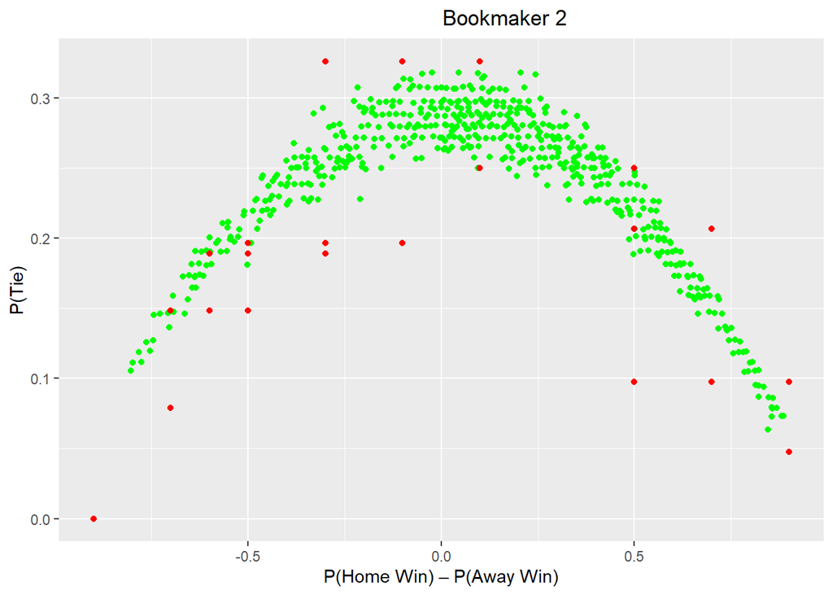

```r
WH_probs <- normalized %>% select(FTR, norm_WHH, norm_WHD, norm_WHA) %>% mutate(norm_WH_HA = norm_WHH - norm_WHA, intervals = cut(norm_WH_HA, breaks = seq(-1, 1, 0.2))) %>% group_by(intervals) %>% mutate(real_draws=sum(FTR=="D")/n()) %>% ungroup()

WH_probs$intervals_number <- as.numeric(PS_probs$intervals)

WH_probs$intervals_number[WH_probs$intervals_number==1]  <- -0.9
WH_probs$intervals_number[WH_probs$intervals_number==2]  <- -0.7
WH_probs$intervals_number[WH_probs$intervals_number==3]  <- -0.6
WH_probs$intervals_number[WH_probs$intervals_number==4]  <- -0.5
WH_probs$intervals_number[WH_probs$intervals_number==5]  <- -0.3
WH_probs$intervals_number[WH_probs$intervals_number==6]  <- -0.1
WH_probs$intervals_number[WH_probs$intervals_number==7]  <-  0.1
WH_probs$intervals_number[WH_probs$intervals_number==8]  <-  0.5
WH_probs$intervals_number[WH_probs$intervals_number==9]  <-  0.7
WH_probs$intervals_number[WH_probs$intervals_number==10] <-  0.9

ggplot(WH_probs) + geom_point(aes(x=norm_WH_HA, y=norm_WHD), color="green") + geom_point(aes(x=intervals_number, y=real_draws), color="red") +  xlab("P(Home Win) – P(Away Win)") + ylab("P(Tie)") + ggtitle("Bookmaker 2") + theme(plot.title=element_text(hjust = 0.6))
```

## Task3

Red card might affect on game result. To observe effect of this, the games which red card occured are removed by filter function while selecting (HR==“0” & AR==“0”).

Then graphs on task 2 are plotted again to compare differances.

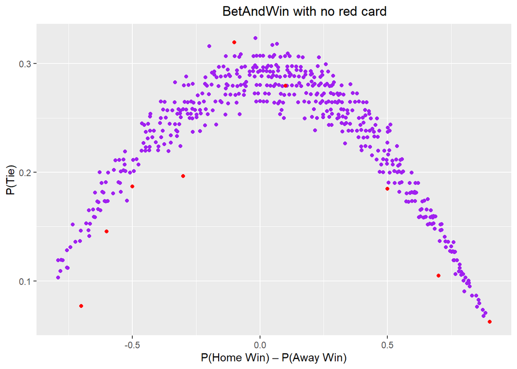

```r
BW_no_red <- normalized %>% select(FTR, norm_BWH, norm_BWD, norm_BWA , HR , AR ) %>% mutate(norm_BW_HA = norm_BWH - norm_BWA, intervals = cut(norm_BW_HA, breaks = seq(-1, 1, 0.2))) %>% group_by(intervals) %>% mutate(real_draws=sum(FTR=="D")/n()) %>% ungroup() %>% filter(HR=="0" & AR=="0")

BW_no_red$intervals_number <- as.numeric(BW_no_red$intervals)

BW_no_red$intervals_number[BW_no_red$intervals_number==1]  <- -0.9
BW_no_red$intervals_number[BW_no_red$intervals_number==2]  <- -0.7
BW_no_red$intervals_number[BW_no_red$intervals_number==3]  <- -0.6
BW_no_red$intervals_number[BW_no_red$intervals_number==4]  <- -0.5
BW_no_red$intervals_number[BW_no_red$intervals_number==5]  <- -0.3
BW_no_red$intervals_number[BW_no_red$intervals_number==6]  <- -0.1
BW_no_red$intervals_number[BW_no_red$intervals_number==7]  <-  0.1
BW_no_red$intervals_number[BW_no_red$intervals_number==8]  <-  0.5
BW_no_red$intervals_number[BW_no_red$intervals_number==9]  <-  0.7
BW_no_red$intervals_number[BW_no_red$intervals_number==10] <-  0.9

ggplot(BW_no_red) + geom_point(aes(x=norm_BW_HA, y=norm_BWD), color="purple") + geom_point(aes(x=intervals_number, y=real_draws), color="red") +  xlab("P(Home Win) – P(Away Win)") + ylab("P(Tie)") + ggtitle("BetAndWin with no red card") + theme(plot.title=element_text(hjust = 0.6))
```

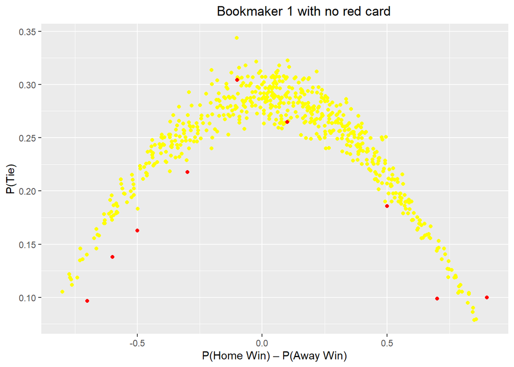

```r
IW_no_red <- normalized %>% select(FTR, norm_IWH, norm_IWD, norm_IWA , HR , AR) %>% mutate(norm_IW_HA = norm_IWH - norm_IWA, intervals = cut(norm_IW_HA, breaks = seq(-1, 1, 0.2))) %>% group_by(intervals) %>% mutate(real_draws=sum(FTR=="D")/n()) %>% ungroup() %>% filter(HR=="0" & AR=="0")

IW_no_red$intervals_number <- as.numeric(IW_no_red$intervals)

IW_no_red$intervals_number[IW_no_red$intervals_number==1]  <- -0.9
IW_no_red$intervals_number[IW_no_red$intervals_number==2]  <- -0.7
IW_no_red$intervals_number[IW_no_red$intervals_number==3]  <- -0.6
IW_no_red$intervals_number[IW_no_red$intervals_number==4]  <- -0.5
IW_no_red$intervals_number[IW_no_red$intervals_number==5]  <- -0.3
IW_no_red$intervals_number[IW_no_red$intervals_number==6]  <- -0.1
IW_no_red$intervals_number[IW_no_red$intervals_number==7]  <-  0.1
IW_no_red$intervals_number[IW_no_red$intervals_number==8]  <-  0.5
IW_no_red$intervals_number[IW_no_red$intervals_number==9]  <-  0.7
IW_no_red$intervals_number[IW_no_red$intervals_number==10] <-  0.9

ggplot(IW_no_red) + geom_point(aes(x=norm_IW_HA, y=norm_IWD), color="yellow") + geom_point(aes(x=intervals_number, y=real_draws), color="red") +  xlab("P(Home Win) – P(Away Win)") + ylab("P(Tie)") + ggtitle("Bookmaker 1 with no red card") + theme(plot.title=element_text(hjust = 0.6))
```

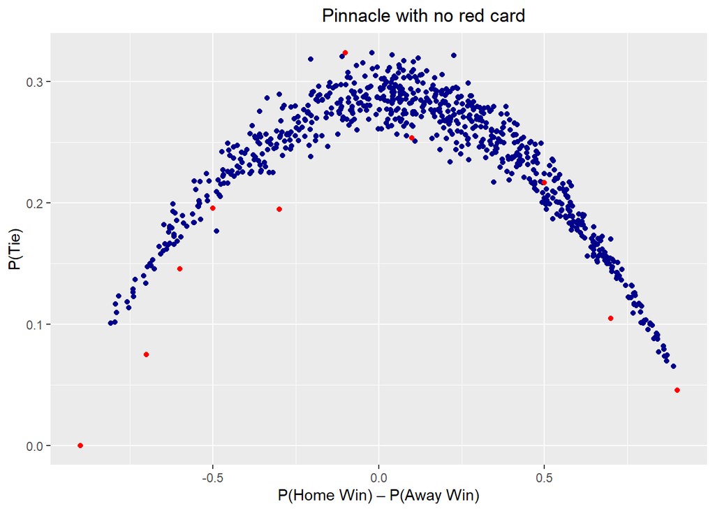

```r
PS_no_red <- normalized %>% select(FTR, norm_PSH, norm_PSD, norm_PSA , HR , AR) %>% mutate(norm_PS_HA = norm_PSH - norm_PSA, intervals = cut(norm_PS_HA, breaks = seq(-1, 1, 0.2))) %>% group_by(intervals) %>% mutate(real_draws=sum(FTR=="D")/n()) %>% ungroup() %>% filter(HR=="0" & AR=="0")

PS_no_red$intervals_number <- as.numeric(PS_no_red$intervals)

PS_no_red$intervals_number[PS_no_red$intervals_number==1]  <- -0.9
PS_no_red$intervals_number[PS_no_red$intervals_number==2]  <- -0.7
PS_no_red$intervals_number[PS_no_red$intervals_number==3]  <- -0.6
PS_no_red$intervals_number[PS_no_red$intervals_number==4]  <- -0.5
PS_no_red$intervals_number[PS_no_red$intervals_number==5]  <- -0.3
PS_no_red$intervals_number[PS_no_red$intervals_number==6]  <- -0.1
PS_no_red$intervals_number[PS_no_red$intervals_number==7]  <-  0.1
PS_no_red$intervals_number[PS_no_red$intervals_number==8]  <-  0.5
PS_no_red$intervals_number[PS_no_red$intervals_number==9]  <-  0.7
PS_no_red$intervals_number[PS_no_red$intervals_number==10] <-  0.9

ggplot(PS_no_red) + geom_point(aes(x=norm_PS_HA, y=norm_PSD), color="darkblue") + geom_point(aes(x=intervals_number, y=real_draws), color="red") +  xlab("P(Home Win) – P(Away Win)") + ylab("P(Tie)") + ggtitle("Pinnacle with no red card") + theme(plot.title=element_text(hjust = 0.6))
```

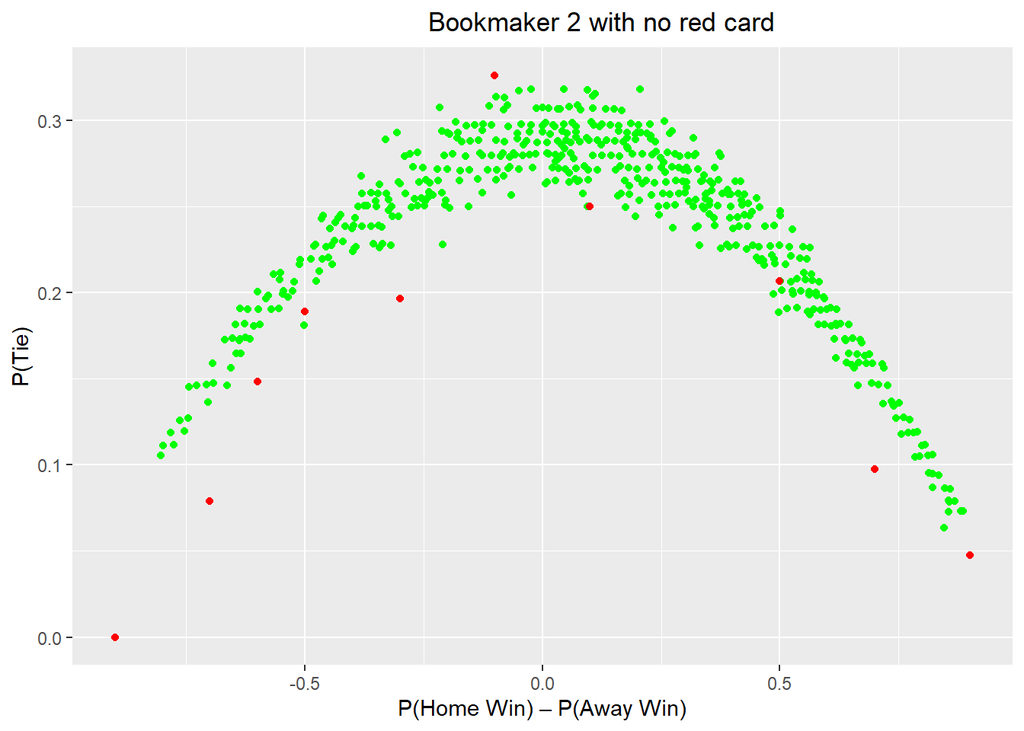

```r
WH_no_red <- normalized %>% select(FTR, norm_WHH, norm_WHD, norm_WHA , HR , AR) %>% mutate(norm_WH_HA = norm_WHH - norm_WHA, intervals = cut(norm_WH_HA, breaks = seq(-1, 1, 0.2))) %>% group_by(intervals) %>% mutate(real_draws=sum(FTR=="D")/n()) %>% ungroup() %>% filter(HR=="0" & AR=="0")

WH_no_red$intervals_number <- as.numeric(WH_no_red$intervals)

WH_no_red$intervals_number[WH_no_red$intervals_number==1]  <- -0.9
WH_no_red$intervals_number[WH_no_red$intervals_number==2]  <- -0.7
WH_no_red$intervals_number[WH_no_red$intervals_number==3]  <- -0.6
WH_no_red$intervals_number[WH_no_red$intervals_number==4]  <- -0.5
WH_no_red$intervals_number[WH_no_red$intervals_number==5]  <- -0.3
WH_no_red$intervals_number[WH_no_red$intervals_number==6]  <- -0.1
WH_no_red$intervals_number[WH_no_red$intervals_number==7]  <-  0.1
WH_no_red$intervals_number[WH_no_red$intervals_number==8]  <-  0.5
WH_no_red$intervals_number[WH_no_red$intervals_number==9]  <-  0.7
WH_no_red$intervals_number[WH_no_red$intervals_number==10] <-  0.9

ggplot(WH_no_red) + geom_point(aes(x=norm_WH_HA, y=norm_WHD), color="green") + geom_point(aes(x=intervals_number, y=real_draws), color="red") +  xlab("P(Home Win) – P(Away Win)") + ylab("P(Tie)") + ggtitle("Bookmaker 2 with no red card") + theme(plot.title=element_text(hjust = 0.6))
```

### References

[1] Jonas Mirza and Niklas Fejes,2016, “Statistical Football Modeling A Study of Football Betting and Implementation of Statistical Algorithms in Premier League”, available online: http://www.it.uu.se/edu/course/homepage/projektTDB/ht15/project16/Project16_Report.pdf

[2] Štrumbelj, E., 2014. On determining probability forecasts from betting odds. International journal of forecasting, 30(4), pp.934-943.

[3] Shin, H.S., 1993. Measuring the incidence of insider trading in a market for state-contingent claims. The Economic Journal, 103(420), pp.1141-1153.